# A Computational Metagenomics Project

Adrian Lee

1 May 2020

```r
#Import the required libraries

library(ggplot2)
library(scales)
library(reshape2)
library(ggrepel)
library(RColorBrewer)
library(rprintf)
library(ggpubr)
library(gridExtra)
library(plot3D)
library(plot3Drgl)
library(plotly)
```

First, work with level 3 (class-level) data

```r
# Read in file
level_3 = read.csv("data/level-3.csv")
classes = as.matrix(level_3[,-c(1,26:30)])

classes
```

Plot correlation heatmap:

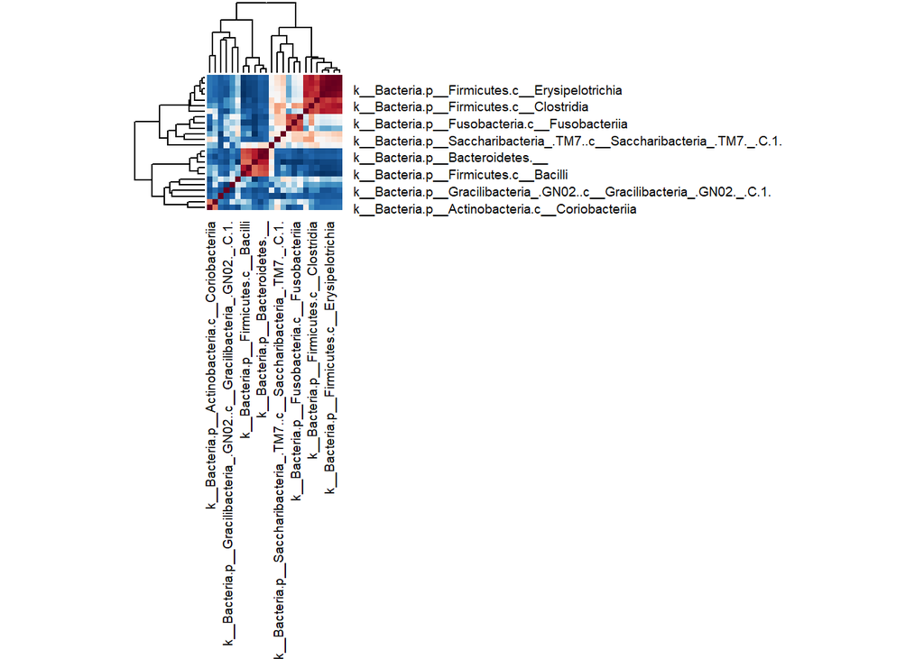

```r
# Correlations between classes
par(oma = c(13,0,0,13), xpd = TRUE)
heatmap(cor(classes), scale = "none", col = rev(colorRampPalette(brewer.pal(11, "RdBu"))(256)), cexRow = 0.7, cexCol = 0.7, margins = c(7.5,7.5))
legend(x = "bottomright", inset = c(-0.7,-0.55), legend = c(1, 0, -1), fill=colorRampPalette(brewer.pal(11, "RdBu"))(3), cex = 0.5)# , inset = c(0, -2)
```

Visualise the distributions of the relative abundance of each class (level 3)

First, select and transform data into the required format

```r
# Relative abundances before and after oil pulling each day
# Select the required data first
before_day_1 = classes[which(level_3[,"Oil.Pulling...Before..2..or.After..1.."] == 2 & level_3[,"Sampling.Day.."] == 1),]
after_day_1 = classes[which(level_3[,"Oil.Pulling...Before..2..or.After..1.."] == 1 & level_3[,"Sampling.Day.."] == 1),]
before_day_16 = classes[which(level_3[,"Oil.Pulling...Before..2..or.After..1.."] == 2 & level_3[,"Sampling.Day.."] == 16),]
after_day_16 = classes[which(level_3[,"Oil.Pulling...Before..2..or.After..1.."] == 1 & level_3[,"Sampling.Day.."] == 16),]
before_day_31 = classes[which(level_3[,"Oil.Pulling...Before..2..or.After..1.."] == 2 & level_3[,"Sampling.Day.."] == 31),]
after_day_31 = classes[which(level_3[,"Oil.Pulling...Before..2..or.After..1.."] == 1 & level_3[,"Sampling.Day.."] == 31),]

# Compute the sums of relative abundances over all samples for each sample collection point
before_day_1_sum = rowSums(before_day_1)
after_day_1_sum = rowSums(after_day_1)
before_day_16_sum = rowSums(before_day_16)
after_day_16_sum = rowSums(after_day_16)
before_day_31_sum = rowSums(before_day_31)
after_day_31_sum = rowSums(after_day_31)
maxlength = max(length(before_day_1_sum), length(after_day_1_sum), length(before_day_16_sum), length(after_day_16_sum), length(before_day_31_sum), length(after_day_31_sum))

# Place sums into a matrix for easier handling
all_abundances_sum_ba_each_day = matrix(data = NA, nrow = maxlength, ncol = 6)
colnames(all_abundances_sum_ba_each_day) = c("Before Day 1", "After Day 1",
                                             "Before Day 16", "After Day 16",
                                             "Before Day 31", "After Day 31")
all_abundances_sum_ba_each_day[,1] = c(before_day_1_sum, rep(NA, maxlength-length(before_day_1_sum)))
all_abundances_sum_ba_each_day[,2] = c(after_day_1_sum, rep(NA, maxlength-length(after_day_1_sum)))
all_abundances_sum_ba_each_day[,3] = c(before_day_16_sum, rep(NA, maxlength-length(before_day_16_sum)))
all_abundances_sum_ba_each_day[,4] = c(after_day_16_sum, rep(NA, maxlength-length(after_day_16_sum)))
all_abundances_sum_ba_each_day[,5] = c(before_day_31_sum, rep(NA, maxlength-length(before_day_31_sum)))
all_abundances_sum_ba_each_day[,6] = c(after_day_31_sum, rep(NA, maxlength-length(after_day_31_sum)))
# Do nothing for missing values
na.pass(all_abundances_sum_ba_each_day)
```

```
##       Before Day 1 After Day 1 Before Day 16 After Day 16 Before Day 31
##  [1,]           95       24278         13145        19375        123894
##  [2,]        16494       22469         18135         6758         20174
##  [3,]        20683       13140         23942         5998         16556
##  [4,]        22898       35683         20397         4701         21198
##  [5,]        19145       18233          6016        48823         26467
##  [6,]        10925        8045         27876        37495         27798
##  [7,]          199       25022         21886        18975         12515
##  [8,]           12       35891          4701        26029         23951
##  [9,]           NA          NA          1529           NA          4477
## [10,]           NA          NA            NA           NA         14387
## [11,]           NA          NA            NA           NA         22212
##       After Day 31
##  [1,]        15804
##  [2,]        25221
##  [3,]        15654
##  [4,]        28181
##  [5,]        19253
##  [6,]           42
##  [7,]        86624
##  [8,]        15511
##  [9,]        45677
## [10,]        14020
## [11,]           NA
```

```r
# Transform (melt) data into a suitable form for subsequent plotting
all_abundances_sum_ba_each_day_melted = melt(all_abundances_sum_ba_each_day)
all_abundances_sum_ba_day_1_melted = melt(all_abundances_sum_ba_each_day[,c(1,2)])
all_abundances_sum_ba_day_16_melted = melt(all_abundances_sum_ba_each_day[,c(3,4)])
all_abundances_sum_ba_day_31_melted = melt(all_abundances_sum_ba_each_day[,c(5,6)])
all_abundances_sum_bb_day1_day_31_melted = melt(all_abundances_sum_ba_each_day[,c(1,5)])
```

Then plot density plots showing relative abundances of CLASSES across all samples between different days

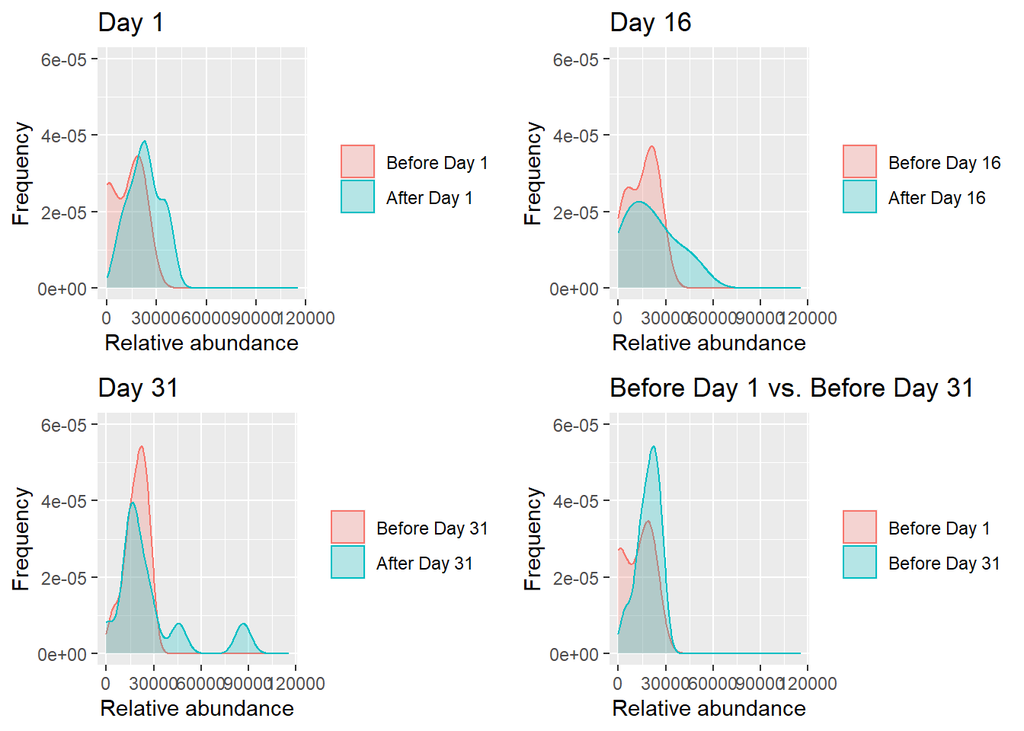

```r
plot1 <- ggplot(all_abundances_sum_ba_day_1_melted, aes(x=value, fill=Var2, colour=Var2, rm.na = TRUE)) +
  geom_density(alpha=0.25) +
  scale_x_continuous(lim = c(0, 115000)) +
  scale_y_continuous(lim = c(0, 6*10^-5)) +
  labs(x = "Relative abundance", y = "Frequency", title = "Day 1") +
  theme(legend.title = element_blank())

plot2 <- ggplot(all_abundances_sum_ba_day_16_melted, aes(x=value, fill=Var2, colour=Var2, rm.na = TRUE)) +
  geom_density(alpha=0.25) +
  scale_x_continuous(lim = c(0, 115000)) +
  scale_y_continuous(lim = c(0, 6*10^-5)) +
  labs(x = "Relative abundance", y = "Frequency", title = "Day 16") +
  theme(legend.title = element_blank())

plot3 <- ggplot(all_abundances_sum_ba_day_31_melted, aes(x=value, fill=Var2, colour=Var2, rm.na = TRUE)) +
  geom_density(alpha=0.25) +
  scale_x_continuous(lim = c(0, 115000)) +
  scale_y_continuous(lim = c(0, 6*10^-5)) +
  labs(x = "Relative abundance", y = "Frequency", title = "Day 31") +
  theme(legend.title = element_blank())

plot4 <- ggplot(all_abundances_sum_bb_day1_day_31_melted, aes(x=value, fill=Var2, colour=Var2, rm.na = TRUE)) +
  geom_density(alpha=0.25) +
  scale_x_continuous(lim = c(0, 115000)) +
  scale_y_continuous(lim = c(0, 6*10^-5)) +
  labs(x = "Relative abundance", y = "Frequency", title = "Before Day 1 vs. Before Day 31") +
  theme(legend.title = element_blank())

# Arrange into a 2x2 format
grid.arrange(plot1, plot2, plot3, plot4, ncol=2)
```

Compare whether there were any statistically significant differences before and after oil pulling on each day, as well as before and after 31 days of oil pulling, using the Mann-Whitney U test

```r
#Statistical significance tests
wilcox.test(all_abundances_sum_ba_each_day[,1], all_abundances_sum_ba_each_day[,2], paired = FALSE, alternative = "less")$p.value
```

```
## [1] 0.02494172
```

```r
wilcox.test(all_abundances_sum_ba_each_day[,3], all_abundances_sum_ba_each_day[,4], paired = FALSE)$p.value
```

```
## [1] 0.5634637
```

```r
wilcox.test(all_abundances_sum_ba_each_day[,5], all_abundances_sum_ba_each_day[,6], paired = FALSE)$statistic
```

```
##  W
## 57
```

```r
wilcox.test(all_abundances_sum_ba_each_day[,1], all_abundances_sum_ba_each_day[,5], paired = FALSE)$p.value
```

```
## [1] 0.05062052
```

```r
#Relative abundances of CLASSES along time
day_1 = classes[which(level_3[,"Sampling.Day.."] == 1),]
day_16 = classes[which(level_3[,"Sampling.Day.."] == 16),]
day_31 = classes[which(level_3[,"Sampling.Day.."] == 31),]

max_mean_min = matrix(NA, ncol = 24, nrow = 9,
                      dimnames = list(c("Day 1", "Day 1", "Day 1",
                                        "Day 16", "Day 16", "Day 16",
                                        "Day 31", "Day 31", "Day 31"),
                                      colnames(classes)))
```

Plot line plot showing the relative abundance of classes The mean, maximum, and minimum relative abundances were first computed. The maximum and minimum were originally computed for generating error bars, however error bars were not plotted in the end since it would be impractical to plot them when they span the entire y axis. Besides, they would clutter up the plot.

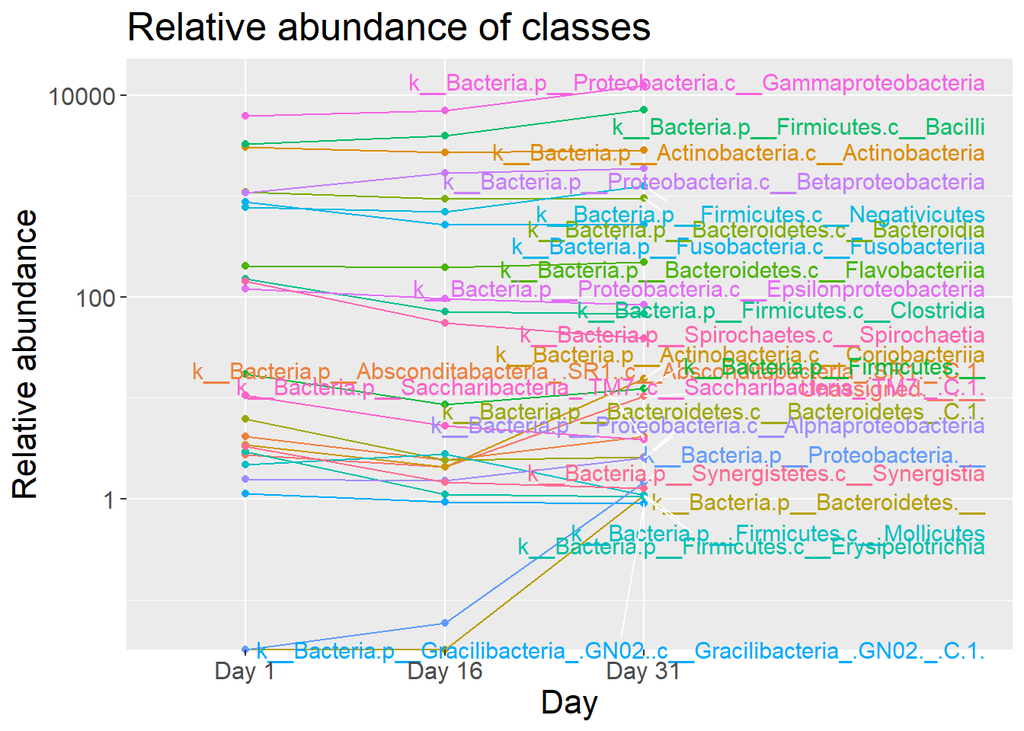

```r
max_mean_min[1,] = apply(day_1, 2, max)
max_mean_min[2,] = apply(day_1, 2, mean)
max_mean_min[3,] = apply(day_1, 2, min)
max_mean_min[4,] = apply(day_16, 2, max)
max_mean_min[5,] = apply(day_16, 2, mean)
max_mean_min[6,] = apply(day_16, 2, min)
max_mean_min[7,] = apply(day_31, 2, max)
max_mean_min[8,] = apply(day_31, 2, mean)
max_mean_min[9,] = apply(day_31, 2, min)
write.csv(max_mean_min, "data/max_mean_min.csv")

# Transform (melt) summary statistics into the required form, merge into a matrix for easier handling
max_mean_min_melted = melt(max_mean_min)

max_mean_min_melted = cbind(max_mean_min_melted, rep(c("max", "mean", "min"), nrow(max_mean_min_melted)/3))
colnames(max_mean_min_melted)[4] = "statistic"
max_mean_min_melted[,3] = as.numeric(max_mean_min_melted[,3])

# Plot line plot with ggplot
line_plot = ggplot(max_mean_min_melted, aes(x=Var1, y=value, group=Var2, color=Var2, fill = "")) +
  coord_cartesian(clip = "off", expand = TRUE, xlim = c(1,4.25)) +
  geom_line(data = subset(max_mean_min_melted, statistic == "mean"), stat = "identity", size = 0.5) +
  geom_point(data = subset(max_mean_min_melted, statistic == "mean"), stat = "identity") +
  geom_text_repel(data = subset(max_mean_min_melted, statistic == "mean" & Var1 == "Day 31"),
            aes(label = Var2, colour = Var2, x = Var1, y = value), size = 4, hjust = -.1, direction = "y", xlim = 4.75, segment.colour = "white") +
  labs(title = "Relative abundance of classes", x = "Day", y = "Relative abundance") +
  scale_y_log10() +
  theme(legend.position = "None",
        axis.text = element_text(size = 12),
        axis.title = element_text(size = 16),
        title = element_text(size = 16))

line_plot
```

Now work with level 6 (genus-level) data

```r
# Read in file
level_6 = read.csv("data/level-6.csv")
genuses = level_6[,-c(1,72,73,76)]

#The relative abundances of (a subset containing) the most abundant genuses
genuses_subset = level_6[,c(7,9,18,31,43,46,63,70)]

day_1_genuses_subset = genuses_subset[which(level_6[,"Sampling.Day.."] == 1),]
day_16_genuses_subset = genuses_subset[which(level_6[,"Sampling.Day.."] == 16),]
day_31_genuses_subset = genuses_subset[which(level_6[,"Sampling.Day.."] == 31),]
day_1_before_genuses_subset = genuses_subset[which(level_6[,"Sampling.Day.."] == 1 & level_6[,"Oil.Pulling...Before..2..or.After..1.."] == 2),]
day_1_after_genuses_subset = genuses_subset[which(level_6[,"Sampling.Day.."] == 1 & level_6[,"Oil.Pulling...Before..2..or.After..1.."] == 1),]
day_16_before_genuses_subset = genuses_subset[which(level_6[,"Sampling.Day.."] == 16 & level_6[,"Oil.Pulling...Before..2..or.After..1.."] == 2),]
day_16_after_genuses_subset = genuses_subset[which(level_6[,"Sampling.Day.."] == 16 & level_6[,"Oil.Pulling...Before..2..or.After..1.."] == 1),]
day_31_before_genuses_subset = genuses_subset[which(level_6[,"Sampling.Day.."] == 31 & level_6[,"Oil.Pulling...Before..2..or.After..1.."] == 2),]
day_31_after_genuses_subset = genuses_subset[which(level_6[,"Sampling.Day.."] == 31 & level_6[,"Oil.Pulling...Before..2..or.After..1.."] == 1),]
```

```r
# Insert p-values into a matrix for easier handling
genuses_subset_day_p_values = matrix(data = NA, nrow = ncol(genuses_subset), ncol = 4)

for (genus in 6:ncol(genuses_subset)){
  genuses_subset_day_p_values[genus,1] = wilcox.test(day_1_before_genuses_subset[,genus], day_31_before_genuses_subset[,genus], paired = FALSE)$p.value
  genuses_subset_day_p_values[genus,2] = wilcox.test(day_1_before_genuses_subset[,genus], day_1_after_genuses_subset[,genus], paired = FALSE)$p.value
  genuses_subset_day_p_values[genus,3] = wilcox.test(day_16_before_genuses_subset[,genus], day_16_after_genuses_subset[,genus], paired = FALSE)$p.value
  genuses_subset_day_p_values[genus,4] = wilcox.test(day_31_before_genuses_subset[,genus], day_31_after_genuses_subset[,genus], paired = FALSE)$p.value
  return(genuses_subset_day_p_values)
}
rownames(genuses_subset_day_p_values) = c("actinomyces", "corynebacterium", "porphyromonas", "streptococcus", "veillonella", "fusobacterium", "haemophilus", "trepenoma")
colnames(genuses_subset_day_p_values) = c("Day 31 Before vs. Day 1 Before",
                                          "Day 1 Before vs. After",
                                          "Day 16 Before vs. After",
                                          "Day 31 Before vs. After")

genuses_subset_day_p_values
```

```
##                 Day 31 Before vs. Day 1 Before Day 1 Before vs. After
## actinomyces                                 NA                     NA
## corynebacterium                             NA                     NA
## porphyromonas                               NA                     NA
## streptococcus                               NA                     NA
## veillonella                                 NA                     NA
## fusobacterium                        0.6495792              0.2697961
## haemophilus                                 NA                     NA
## trepenoma                                   NA                     NA
##                 Day 16 Before vs. After Day 31 Before vs. After
## actinomyces                          NA                      NA
## corynebacterium                      NA                      NA
## porphyromonas                        NA                      NA
## streptococcus                        NA                      NA
## veillonella                          NA                      NA
## fusobacterium                 0.8883587                0.971904
## haemophilus                          NA                      NA
## trepenoma                            NA                      NA
```

Explore the use of a balloon plot of relative abundances of top GENUSES for each sample (not used in the end)

```r
# Select the required data
genuses_sample_name = rbind(genuses[,-c(71,72)], colSums(genuses))
genuses_sample_name = cbind(genuses_sample_name, c(as.character(level_6[,72]),NA))
genuses_sample_name_ordered_by_sum = genuses_sample_name[,order(as.numeric(genuses_sample_name[55,]), decreasing = FALSE)]
genuses_sample_name_ordered_by_sum_samples = genuses_sample_name_ordered_by_sum[55,]
genuses_sample_name_ordered_by_sum = genuses_sample_name_ordered_by_sum[-55,]
colnames(genuses_sample_name_ordered_by_sum)[71] = "sample_name"

# Transform data into the required form
genuses_sample_name_ordered_by_sum_melted =
melt(genuses_sample_name_ordered_by_sum[,c(ncol(genuses_sample_name_ordered_by_sum)-(10:1),ncol(genuses_sample_name_ordered_by_sum))]) # -> top 10
```

[figure not shown]

```r
# Plot the balloon plot
ggballoonplot(genuses_sample_name_ordered_by_sum_melted, x = "sample_name", y = "variable")
```

Using ggplot, plot a heatmap visualise the relative abundances of the 30 most abundant genera at each sample collection point

[figure not shown]

```r
# Select the required data
day_1_before_genuses = genuses[which(level_6[,"Sampling.Day.."] == 1 & level_6[,"Oil.Pulling...Before..2..or.After..1.."] == 2),]
day_1_after_genuses = genuses[which(level_6[,"Sampling.Day.."] == 1 & level_6[,"Oil.Pulling...Before..2..or.After..1.."] == 1),]
day_16_before_genuses = genuses[which(level_6[,"Sampling.Day.."] == 16 & level_6[,"Oil.Pulling...Before..2..or.After..1.."] == 2),]
day_16_after_genuses = genuses[which(level_6[,"Sampling.Day.."] == 16 & level_6[,"Oil.Pulling...Before..2..or.After..1.."] == 1),]
day_31_before_genuses = genuses[which(level_6[,"Sampling.Day.."] == 31 & level_6[,"Oil.Pulling...Before..2..or.After..1.."] == 2),]
day_31_after_genuses = genuses[which(level_6[,"Sampling.Day.."] == 31 & level_6[,"Oil.Pulling...Before..2..or.After..1.."] == 1),]

# Compute the sums over all samples at each sampling point
day_1_before_genuses_sum = colSums(day_1_before_genuses)
day_1_after_genuses_sum = colSums(day_1_after_genuses)
day_16_before_genuses_sum = colSums(day_16_before_genuses)
day_16_after_genuses_sum = colSums(day_16_after_genuses)
day_31_before_genuses_sum = colSums(day_31_before_genuses)
day_31_after_genuses_sum = colSums(day_31_after_genuses)

# Insert sums into matrix for easier handling
all_days_genuses_sum = rbind(day_1_before_genuses_sum, day_1_after_genuses_sum, day_16_before_genuses_sum,
                             day_16_after_genuses_sum, day_31_before_genuses_sum, day_31_after_genuses_sum)[,-c(71,72)]

# Sort columns (i.e. genera) according to the total relative abundance, so that the most abundant ones are on the top of the plot
all_days_genuses_sum = all_days_genuses_sum[,order(colSums(all_days_genuses_sum), decreasing = FALSE)]

# Transform (melt) data into the required form
all_days_genuses_sum_melted = melt(all_days_genuses_sum[,c(ncol(all_days_genuses_sum)-(29:0))])
all_days_genuses_sum_melted[,"value"] = sqrt(all_days_genuses_sum_melted[,"value"])

# Plot the heatmap
genera_heatmap = ggplot(all_days_genuses_sum_melted, mapping = aes(x = Var1, y = Var2, fill = value)) +
  geom_tile() +
  scale_fill_gradientn(colours = c("Blue", "White", "Red"), values = c(0,0.5,1), limits = c(0,400)) +
  scale_x_discrete("Day", labels = c("Day 1 Before", "Day 1 After", "Day 16 Before", "Day 16 After", "Day 31 Before", "Day 31 After")) +
  ylab("Genera") +
  labs(fill = "Square root of relative abundance")

genera_heatmap
```

Now analyse beta diversity

```r
# Read in files for each beta diversity metric
bray_curtis = read.table("diversity_metrics/beta/bray_curtis-distance_matrix.tsv")
generalized_unifrac = read.table("diversity_metrics/beta/generalized_unifrac-distance_matrix.tsv")
jaccard = read.table("diversity_metrics/beta/jaccard-distance_matrix.tsv")
unweighted_unifrac = read.table("diversity_metrics/beta/unweighted_unifrac-distance_matrix.tsv")
weighted_normalized_unifrac = read.table("diversity_metrics/beta/weighted_normalized_unifrac-distance_matrix.tsv")
weighted_unifrac = read.table("diversity_metrics/beta/weighted_unifrac-distance_matrix.tsv")

# Select samples for each day and before and after oil pulling
sampling.day.1 = c("515rcbc257", "515rcbc263", "515rcbc479", "515rcbc454", "515rcbc239", "515rcbc254", "515rcbc251", "515rcbc245", "515rcbc269",
                   "515rcbc242", "515rcbc467", "515rcbc461", "515rcbc482", "515rcbc266", "515rcbc248", "515rcbc458")
sampling.day.16 = c("515rcbc255", "515rcbc267", "515rcbc264", "515rcbc495", "515rcbc243", "515rcbc464", "515rcbc240", "515rcbc249", "515rcbc470",
                    "515rcbc261", "515rcbc252", "515rcbc480", "515rcbc456", "515rcbc462", "515rcbc270", "515rcbc258", "515rcbc483")
sampling.day.31 = c("515rcbc247", "515rcbc496", "515rcbc484", "515rcbc271", "515rcbc472", "515rcbc259", "515rcbc265", "515rcbc256", "515rcbc466",
                    "515rcbc457", "515rcbc471", "515rcbc262", "515rcbc478", "515rcbc465", "515rcbc253", "515rcbc268", "515rcbc493", "515rcbc241",
                    "515rcbc250", "515rcbc244", "515rcbc477")
before.oil.pulling = c("515rcbc454", "515rcbc254", "515rcbc242", "515rcbc467", "515rcbc482", "515rcbc266", "515rcbc248", "515rcbc458", "515rcbc255",
                       "515rcbc267", "515rcbc495", "515rcbc243", "515rcbc249", "515rcbc261", "515rcbc456", "515rcbc462", "515rcbc483", "515rcbc496",
                       "515rcbc484", "515rcbc256", "515rcbc457", "515rcbc471", "515rcbc262", "515rcbc465", "515rcbc268", "515rcbc250", "515rcbc244",
                       "515rcbc477")
after.oil.pulling = c("515rcbc257", "515rcbc263", "515rcbc479", "515rcbc239", "515rcbc251", "515rcbc245", "515rcbc269", "515rcbc461", "515rcbc264",
                      "515rcbc464", "515rcbc240", "515rcbc470", "515rcbc252", "515rcbc480", "515rcbc270", "515rcbc258", "515rcbc247", "515rcbc271",
                      "515rcbc472", "515rcbc259", "515rcbc265", "515rcbc466", "515rcbc478", "515rcbc253", "515rcbc493", "515rcbc241")
```

Principle coordinate analysis (PCoA) for dimensionality reduction and for finding out the percentage variance explained by the top three components

```r
# Compute principle components
pc.bray_curtis = prcomp(bray_curtis)
pc.generalized_unifrac = prcomp(generalized_unifrac)
pc.jaccard = prcomp(jaccard)
pc.unweighted_unifrac = prcomp(unweighted_unifrac)
pc.weighted_normalized_unifrac = prcomp(weighted_normalized_unifrac)
pc.weighted_unifrac = prcomp(weighted_unifrac)

# Find out percentage variance explained
pc.bray_curtis$sdev[1:3]^2/sum(pc.bray_curtis$sdev^2)
```

```
## [1] 0.50336580 0.12991948 0.08165927
```

```r
pc.generalized_unifrac$sdev[1:3]^2/sum(pc.generalized_unifrac$sdev^2)
```

```
## [1] 0.5490408 0.1998453 0.1485332
```

```r
pc.jaccard$sdev[1:3]^2/sum(pc.jaccard$sdev^2)
```

```
## [1] 0.29801035 0.15182944 0.09269684
```

```r
pc.unweighted_unifrac$sdev[1:3]^2/sum(pc.unweighted_unifrac$sdev^2)
```

```
## [1] 0.5497751 0.2018596 0.1474720
```

```r
pc.weighted_normalized_unifrac$sdev[1:3]^2/sum(pc.weighted_normalized_unifrac$sdev^2)
```

```
## [1] 0.5490408 0.1998453 0.1485332
```

```r
pc.weighted_unifrac$sdev[1:3]^2/sum(pc.weighted_unifrac$sdev^2)
```

```
## [1] 0.5497751 0.2018596 0.1474720
```

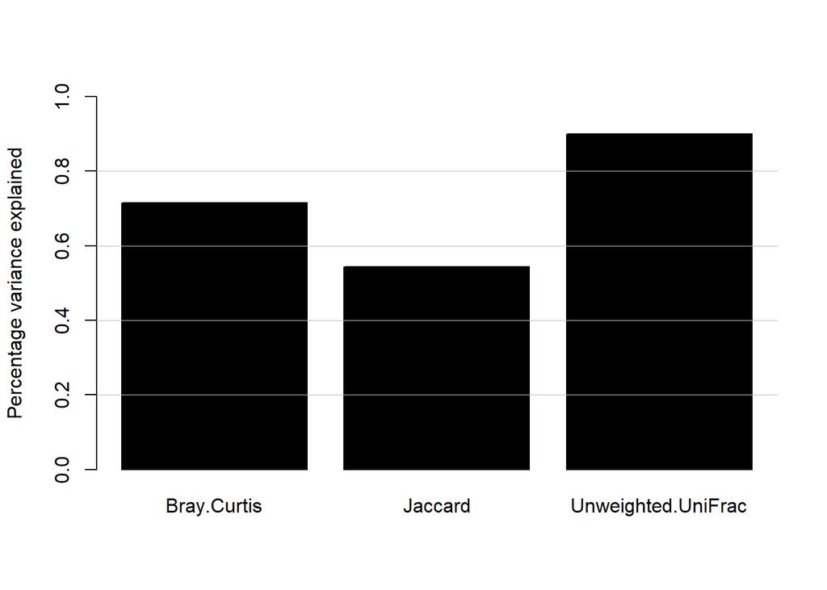

```
## numeric(0)
```

```r
# Create barplot to visualise percentage variance explained for the all metrics
bar.plot = t(data.frame("Bray Curtis" = sum(pc.bray_curtis$sdev[1:3]^2/sum(pc.bray_curtis$sdev^2)),
                        "Generalized UniFrac" = sum(pc.generalized_unifrac$sdev[1:3]^2/sum(pc.generalized_unifrac$sdev^2)),
                        "Jaccard" = sum(pc.jaccard$sdev[1:3]^2/sum(pc.jaccard$sdev^2)),
                        "Unweighted UniFrac" = sum(pc.unweighted_unifrac$sdev[1:3]^2/sum(pc.unweighted_unifrac$sdev^2)),
                        "Weighted Normalized UniFrac" = sum(pc.weighted_normalized_unifrac$sdev[1:3]^2/sum(pc.weighted_normalized_unifrac$sdev^2)),
                        "Weighted UniFrac" = sum(pc.weighted_unifrac$sdev[1:3]^2/sum(pc.weighted_unifrac$sdev^2))))

# Only the three representative metrics (Bray Curtis, Jaccard, and unweighted UniFrac) were plotted
barplot(bar.plot[c(1,3,4),1], ylim = c(0,1), ylab = "Percentage variance explained", col = "black") +
  grid(NA, 5, lty = 1, col = "grey", lwd = 0.5)
```

```r
print(sprintf("The percentage variance explained is %3f", pc.bray_curtis$sdev[1:3]^2/sum(pc.bray_curtis$sdev^2)))
```

```
## [1] "The percentage variance explained is 0.503366"
## [2] "The percentage variance explained is 0.129919"
## [3] "The percentage variance explained is 0.081659"
```

Plot 3D scatter plots of PCoA results The section immediately below transforms results into the required format (a tedious process…)

```r
pc.bray_curtis.grouped = data.frame(cbind(pc.bray_curtis$x[,1:3], ba = rep(NA, nrow(pc.bray_curtis$x)), group = rep(NA, nrow(pc.bray_curtis$x)), colour = rep(NA, nrow(pc.bray_curtis$x))))

pc.generalized_unifrac.grouped = data.frame(cbind(pc.generalized_unifrac$x[,1:3], ba = rep(NA, nrow(pc.generalized_unifrac$x)), group = rep(NA, nrow(pc.generalized_unifrac$x)), colour = rep(NA, nrow(pc.generalized_unifrac$x))))

pc.jaccard.grouped = data.frame(cbind(pc.jaccard$x[,1:3], ba = rep(NA, nrow(pc.jaccard$x)), group = rep(NA, nrow(pc.jaccard$x)), colour = rep(NA, nrow(pc.jaccard$x))))

pc.unweighted_unifrac.grouped = data.frame(cbind(pc.unweighted_unifrac$x[,1:3], ba = rep(NA, nrow(pc.unweighted_unifrac$x)), group = rep(NA, nrow(pc.unweighted_unifrac$x)), colour = rep(NA, nrow(pc.unweighted_unifrac$x))))

pc.weighted_normalized_unifrac.grouped = data.frame(cbind(pc.weighted_normalized_unifrac$x[,1:3], ba = rep(NA, nrow(pc.weighted_normalized_unifrac$x)), group = rep(NA, nrow(pc.weighted_normalized_unifrac$x)), colour = rep(NA, nrow(pc.weighted_normalized_unifrac$x))))

pc.weighted_unifrac.grouped = data.frame(cbind(pc.weighted_unifrac$x[,1:3], ba = rep(NA, nrow(pc.weighted_unifrac$x)), group = rep(NA, nrow(pc.weighted_unifrac$x)), colour = rep(NA, nrow(pc.weighted_unifrac$x))))

scatter.grouped = function(grouped){
  grouped[intersect(sampling.day.1, before.oil.pulling),"group"] = "Before Day 1"
  grouped[intersect(sampling.day.1, after.oil.pulling),"group"] = "After Day 1"
  grouped[intersect(sampling.day.16, before.oil.pulling),"group"] = "Before Day 16"
  grouped[intersect(sampling.day.16, after.oil.pulling),"group"] = "After Day 16"
  grouped[intersect(sampling.day.31, before.oil.pulling),"group"] = "Before Day 31"
  grouped[intersect(sampling.day.31, after.oil.pulling),"group"] = "After Day 31"
  grouped[intersect(sampling.day.1, before.oil.pulling),"colour"] = "#F8766D"
  grouped[intersect(sampling.day.1, after.oil.pulling),"colour"] = "#F6F86D"
  grouped[intersect(sampling.day.16, before.oil.pulling),"colour"] = "#00BA38"
  grouped[intersect(sampling.day.16, after.oil.pulling),"colour"] = "#00BCD8"
  grouped[intersect(sampling.day.31, before.oil.pulling),"colour"] = "#000000"
  grouped[intersect(sampling.day.31, after.oil.pulling),"colour"] = "#E76BF3"
  grouped[before.oil.pulling,"ba"] = "Before"
  grouped[after.oil.pulling,"ba"] = "After"
  return(grouped)
}

pc.bray_curtis.grouped = scatter.grouped(pc.bray_curtis.grouped)
pc.generalized_unifrac.grouped = scatter.grouped(pc.generalized_unifrac.grouped)
pc.jaccard.grouped = scatter.grouped(pc.jaccard.grouped)
pc.unweighted_unifrac.grouped = scatter.grouped(pc.unweighted_unifrac.grouped)
pc.weighted_normalized_unifrac.grouped = scatter.grouped(pc.weighted_normalized_unifrac.grouped)
pc.weighted_unifrac.grouped = scatter.grouped(pc.weighted_unifrac.grouped)

pc.bray_curtis.grouped.1.31 = pc.bray_curtis.grouped[intersect(c(sampling.day.1,sampling.day.31), before.oil.pulling),]
pc.jaccard.grouped.1.31 = pc.jaccard.grouped[intersect(c(sampling.day.1,sampling.day.31), before.oil.pulling),]
pc.unweighted_unifrac.grouped.1.31 = pc.unweighted_unifrac.grouped[intersect(c(sampling.day.1,sampling.day.31), before.oil.pulling),]
```

Finally, plot the 3D scatter plots (plots may not show up properly since RMarkdown does not always produce the same results as RStudio)

```r
par(mfrow=c(3,2), mar=c(1,0,1,0))

bray_curtis.scatter = scatter3D(pc.bray_curtis.grouped[,1], pc.bray_curtis.grouped[,2], pc.bray_curtis.grouped[,3],
                                xlab = sprintf("\nPrincipal Component 1 \n(%.3f%%)", pc.bray_curtis$sdev[1:3]^2/sum(pc.bray_curtis$sdev^2)*100)[1],
                                ylab = sprintf("\nPrincipal Component 2 \n(%.3f%%)", pc.bray_curtis$sdev[1:3]^2/sum(pc.bray_curtis$sdev^2)*100)[2],
                                zlab = sprintf("\nPrincipal Component 3 \n(%.3f%%)", pc.bray_curtis$sdev[1:3]^2/sum(pc.bray_curtis$sdev^2)*100)[3],
                                col = pc.bray_curtis.grouped[,6], type = "p", angle = 45, box = TRUE, colvar = NULL,
                                theta = 20, phi = 20, main = "PCoA of Bray Curtis Distances", cex.main = 1.3,
                                alpha = 0.5, pch = 16, cex = 2)

jaccard.scatter = scatter3D(pc.jaccard.grouped[,1], pc.jaccard.grouped[,2], pc.jaccard.grouped[,3],
                     xlab = sprintf("\nPrincipal Component 1 \n(%.3f%%)", pc.jaccard$sdev[1:3]^2/sum(pc.jaccard$sdev^2)*100)[1],
                     ylab = sprintf("\nPrincipal Component 2 \n(%.3f%%)", pc.jaccard$sdev[1:3]^2/sum(pc.jaccard$sdev^2)*100)[2],
                     zlab = sprintf("\nPrincipal Component 3 \n(%.3f%%)", pc.jaccard$sdev[1:3]^2/sum(pc.jaccard$sdev^2)*100)[3],
                     col = pc.jaccard.grouped[,6], type = "p", angle = 45, box = TRUE, colvar = NULL,
                     theta = 20, phi = 20, main = "PCoA of Jaccard Distances", cex.main = 1.3,
                     alpha = 0.5, pch = 16, cex = 2)

unweighted_unifrac.scatter = scatter3D(pc.unweighted_unifrac.grouped[,1], pc.unweighted_unifrac.grouped[,2], pc.unweighted_unifrac.grouped[,3],
                                xlab = sprintf("\nPrincipal Component 1 \n(%.3f%%)", pc.unweighted_unifrac$sdev[1:3]^2/sum(pc.unweighted_unifrac$sdev^2)*100)[1],
                                ylab = sprintf("\nPrincipal Component 2 \n(%.3f%%)", pc.unweighted_unifrac$sdev[1:3]^2/sum(pc.unweighted_unifrac$sdev^2)*100)[2],
                                zlab = sprintf("\nPrincipal Component 3 \n(%.3f%%)", pc.unweighted_unifrac$sdev[1:3]^2/sum(pc.unweighted_unifrac$sdev^2)*100)[3],
                                col = pc.unweighted_unifrac.grouped[,6], type = "p", angle = 45, box = TRUE, colvar = NULL,
                                theta = 20, phi = 20, main = "PCoA of Unweighted UniFrac Distances", cex.main = 1.3,
                                alpha = 0.5, pch = 16, cex = 2)

bray_curtis.scatter.1.31 = scatter3D(pc.bray_curtis.grouped.1.31[,1], pc.bray_curtis.grouped.1.31[,2], pc.bray_curtis.grouped.1.31[,3],
                                     xlab = sprintf("\nPrincipal Component 1 \n(%.3f%%)", pc.bray_curtis$sdev[1:3]^2/sum(pc.bray_curtis$sdev^2)*100)[1],
                                     ylab = sprintf("\nPrincipal Component 2 \n(%.3f%%)", pc.bray_curtis$sdev[1:3]^2/sum(pc.bray_curtis$sdev^2)*100)[2],
                                     zlab = sprintf("\nPrincipal Component 3 \n(%.3f%%)", pc.bray_curtis$sdev[1:3]^2/sum(pc.bray_curtis$sdev^2)*100)[3],
                                     col = pc.bray_curtis.grouped.1.31[,6], type = "p", angle = 45, box = TRUE, colvar = NULL,
                                     theta = 20, phi = 20, cex.main = 1.3,
                                     alpha = 0.5, pch = 16, cex = 2)

jaccard.scatter.1.31 = scatter3D(pc.jaccard.grouped.1.31[,1], pc.jaccard.grouped.1.31[,2], pc.jaccard.grouped.1.31[,3],
                                 xlab = sprintf("\nPrincipal Component 1 \n(%.3f%%)", pc.jaccard$sdev[1:3]^2/sum(pc.jaccard$sdev^2)*100)[1],
                                 ylab = sprintf("\nPrincipal Component 2 \n(%.3f%%)", pc.jaccard$sdev[1:3]^2/sum(pc.jaccard$sdev^2)*100)[2],
                                 zlab = sprintf("\nPrincipal Component 3 \n(%.3f%%)", pc.jaccard$sdev[1:3]^2/sum(pc.jaccard$sdev^2)*100)[3],
                                 col = pc.jaccard.grouped.1.31[,6], type = "p", angle = 45, box = TRUE, colvar = NULL,
                                 theta = 20, phi = 20, cex.main = 1.3,
                                 alpha = 0.5, pch = 16, cex = 2)

unweighted_unifrac.scatter.1.31 = scatter3D(pc.unweighted_unifrac.grouped.1.31[,1], pc.unweighted_unifrac.grouped.1.31[,2], pc.unweighted_unifrac.grouped.1.31[,3],
                                            xlab = sprintf("\nPrincipal Component 1 \n(%.3f%%)", pc.unweighted_unifrac$sdev[1:3]^2/sum(pc.unweighted_unifrac$sdev^2)*100)[1],
                                            ylab = sprintf("\nPrincipal Component 2 \n(%.3f%%)", pc.unweighted_unifrac$sdev[1:3]^2/sum(pc.unweighted_unifrac$sdev^2)*100)[2],
                                            zlab = sprintf("\nPrincipal Component 3 \n(%.3f%%)", pc.unweighted_unifrac$sdev[1:3]^2/sum(pc.unweighted_unifrac$sdev^2)*100)[3],
                                            col = pc.unweighted_unifrac.grouped.1.31[,6], type = "p", angle = 45, box = TRUE, colvar = NULL,
                                            theta = 20, phi = 20, cex.main = 1.3,
                                            alpha = 0.5, pch = 16, cex = 2)
```

[figure not shown]

```r
generalized_unifrac.scatter = scatter3D(pc.generalized_unifrac.grouped[,1], pc.generalized_unifrac.grouped[,2], pc.generalized_unifrac.grouped[,3],
                                        xlab = sprintf("\nPrincipal Component 1 \n(%.3f%%)", pc.generalized_unifrac$sdev[1:3]^2/sum(pc.generalized_unifrac$sdev^2)*100)[1],
                                        ylab = sprintf("\nPrincipal Component 2 \n(%.3f%%)", pc.generalized_unifrac$sdev[1:3]^2/sum(pc.generalized_unifrac$sdev^2)*100)[2],
                                        zlab = sprintf("\nPrincipal Component 3 \n(%.3f%%)", pc.generalized_unifrac$sdev[1:3]^2/sum(pc.generalized_unifrac$sdev^2)*100)[3],
                                        col = pc.jaccard.grouped[,6], type = "p", angle = 45, box = TRUE, colvar = NULL,
                                        theta = 20, phi = 20, main = "PCA of Generalized UniFrac Distances", cex.main = 1.3,
                                        alpha = 0.5, pch = 16, cex = 2)

weighted_normalized_unifrac.scatter = scatter3D(pc.weighted_normalized_unifrac.grouped[,1], pc.weighted_normalized_unifrac.grouped[,2], pc.weighted_normalized_unifrac.grouped[,3],
                                                xlab = sprintf("\nPrincipal Component 1 \n(%.3f%%)", pc.weighted_normalized_unifrac$sdev[1:3]^2/sum(pc.weighted_normalized_unifrac$sdev^2)*100)[1],
                                                ylab = sprintf("\nPrincipal Component 2 \n(%.3f%%)", pc.weighted_normalized_unifrac$sdev[1:3]^2/sum(pc.weighted_normalized_unifrac$sdev^2)*100)[2],
                                                zlab = sprintf("\nPrincipal Component 3 \n(%.3f%%)", pc.weighted_normalized_unifrac$sdev[1:3]^2/sum(pc.weighted_normalized_unifrac$sdev^2)*100)[3],
                                                col = pc.weighted_normalized_unifrac.grouped[,6], type = "p", angle = 45, box = TRUE, colvar = NULL,
                                                theta = 20, phi = 20, main = "PCA of Weighted Normalized UniFrac Distances", cex.main = 1.3,
                                                alpha = 0.5, pch = 16, cex = 2)

weighted_unifrac.scatter = scatter3D(pc.weighted_unifrac.grouped[,1], pc.weighted_unifrac.grouped[,2], pc.weighted_unifrac.grouped[,3],
                                     xlab = sprintf("\nPrincipal Component 1 \n(%.3f%%)", pc.weighted_unifrac$sdev[1:3]^2/sum(pc.weighted_unifrac$sdev^2)*100)[1],
                                     ylab = sprintf("\nPrincipal Component 2 \n(%.3f%%)", pc.weighted_unifrac$sdev[1:3]^2/sum(pc.weighted_unifrac$sdev^2)*100)[2],
                                     zlab = sprintf("\nPrincipal Component 3 \n(%.3f%%)", pc.weighted_unifrac$sdev[1:3]^2/sum(pc.weighted_unifrac$sdev^2)*100)[3],
                                     col = pc.weighted_unifrac.grouped[,6], type = "p", angle = 45, box = TRUE, colvar = NULL,
                                     theta = 20, phi = 20, main = "PCA of Weighted UniFrac Distances", cex.main = 1.3,
                                     alpha = 0.5, pch = 16, cex = 2)

plot(pc.weighted_unifrac.grouped[,1], pc.weighted_unifrac.grouped[,2],
                                     xlab = sprintf("\nPrincipal Component 1 \n(%.3f%%)", pc.weighted_unifrac$sdev[1:3]^2/sum(pc.weighted_unifrac$sdev^2)*100)[1],
                                     ylab = sprintf("\nPrincipal Component 1 \n(%.3f%%)", pc.weighted_unifrac$sdev[1:3]^2/sum(pc.weighted_unifrac$sdev^2)*100)[2],
                                     col = pc.weighted_unifrac.grouped[,6], type = "p", angle = 45, box = TRUE, colvar = NULL,
                                     theta = 20, phi = 20, main = "PCA of Weighted UniFrac Distances", cex.main = 1.3,
                                     alpha = 0.5, pch = 16, cex = 2, legend = TRUE)

dev.off()
```

Plot box plots to visualise the distributions of beta diversity metrics Again, the section immediately below transforms results into the required format

```r
bray_curtis.grouped = cbind(bray_curtis, ba = rep(NA, nrow(pc.bray_curtis$x)),group = rep(NA, nrow(bray_curtis)), day = rep(NA, nrow(bray_curtis)))

generalized_unifrac.grouped = cbind(generalized_unifrac, ba = rep(NA, nrow(pc.generalized_unifrac$x)), group = rep(NA, nrow(generalized_unifrac)), day = rep(NA, nrow(generalized_unifrac)))

jaccard.grouped = cbind(jaccard, ba = rep(NA, nrow(pc.jaccard$x)), group = rep(NA, nrow(jaccard)), day = rep(NA, nrow(jaccard)))

unweighted_unifrac.grouped = cbind(unweighted_unifrac, ba = rep(NA, nrow(pc.unweighted_unifrac$x)), group = rep(NA, nrow(unweighted_unifrac)), day = rep(NA, nrow(unweighted_unifrac)))

weighted_normalized_unifrac.grouped = cbind(weighted_normalized_unifrac, ba = rep(NA, nrow(pc.unweighted_unifrac$x)), group = rep(NA, nrow(weighted_normalized_unifrac)), day = rep(NA, nrow(weighted_normalized_unifrac)))

weighted_unifrac.grouped = cbind(weighted_unifrac, ba = rep(NA, nrow(pc.weighted_unifrac$x)), group = rep(NA, nrow(weighted_unifrac)), day = rep(NA, nrow(weighted_unifrac)))

box.grouped = function(grouped){
  grouped[intersect(sampling.day.1, before.oil.pulling),"group"] = "Before Day 1"
  grouped[intersect(sampling.day.1, after.oil.pulling),"group"] = "After Day 1"
  grouped[intersect(sampling.day.16, before.oil.pulling),"group"] = "Before Day 16"
  grouped[intersect(sampling.day.16, after.oil.pulling),"group"] = "After Day 16"
  grouped[intersect(sampling.day.31, before.oil.pulling),"group"] = "Before Day 31"
  grouped[intersect(sampling.day.31, after.oil.pulling),"group"] = "After Day 31"
  grouped[sampling.day.1,"day"] = "Day 1"
  grouped[sampling.day.16,"day"] = "Day 16"
  grouped[sampling.day.31,"day"] = "Day 31"
  grouped[before.oil.pulling,"ba"] = "Before"
  grouped[after.oil.pulling,"ba"] = "After"
  grouped$group = factor(grouped$group, levels = c("Before Day 1","After Day 1","Before Day 16","After Day 16","Before Day 31","After Day 31"))
  return(grouped)
}

bray_curtis.grouped = box.grouped(bray_curtis.grouped)
generalized_unifrac.grouped = box.grouped(generalized_unifrac.grouped)
jaccard.grouped = box.grouped(jaccard.grouped)
unweighted_unifrac.grouped = box.grouped(unweighted_unifrac.grouped)
weighted_normalized_unifrac.grouped = box.grouped(weighted_normalized_unifrac.grouped)
weighted_unifrac.grouped = box.grouped(weighted_unifrac.grouped)

bray_curtis.grouped.melted = melt(bray_curtis.grouped)
generalized_unifrac.grouped.melted = melt(generalized_unifrac.grouped)
jaccard.grouped.melted = melt(jaccard.grouped)
unweighted_unifrac.grouped.melted = melt(unweighted_unifrac.grouped)
weighted_normalized_unifrac.grouped.melted = melt(weighted_normalized_unifrac.grouped)
weighted_unifrac.grouped.melted = melt(weighted_unifrac.grouped)
```

Plot the boxplots

```r
bray_curtis.box = ggplot(bray_curtis.grouped.melted, aes(x = factor(group, levels = levels(factor(group))), y = value, color = group)) +
  geom_boxplot() +
  labs(title = "Bray Curtis", x = "", y = "Distance") +
  facet_wrap(~ day, scales = "free_x") +
  scale_x_discrete(labels = c("Before", "After")) +
  scale_y_continuous(limits = c(0,1)) +
  theme(legend.position = "none")
  scale_color_manual(name = "group",
                     breaks = c("Before Day 1","After Day 1","Before Day 16","After Day 16","Before Day 31","After Day 31"),
                     values = c("#F8766D", "#F6F86D", "#00BA38", "#00BCD8", "#000000", "#E76BF3"))
```

[output not shown]

```r
generalized_unifrac.box = ggplot(generalized_unifrac.grouped.melted, aes(x = factor(group, levels = levels(factor(group))), y = value, color = group)) +
  geom_boxplot() +
  labs(title = "Generalized UniFrac", x = "", y = "Distance") +
  facet_wrap(~ day, scales = "free_x") +
  scale_x_discrete(labels = c("Before", "After")) +
  scale_y_continuous(limits = c(0,1)) +
  theme(legend.position = "none")
  scale_color_manual(name = "group",
                     breaks = c("Before Day 1","After Day 1","Before Day 16","After Day 16","Before Day 31","After Day 31"),
                     values = c("#F8766D", "#F6F86D", "#00BA38", "#00BCD8", "#000000", "#E76BF3"))
```

[output not shown]

```r
jaccard.box = ggplot(jaccard.grouped.melted, aes(x = factor(group, levels = levels(factor(group))), y = value, color = group)) +
  geom_boxplot() +
  labs(title = "Jaccard", x = "", y = "Distance") +
  facet_wrap(~ day, scales = "free_x") +
  scale_x_discrete(labels = c("Before", "After")) +
  scale_y_continuous(limits = c(0,1)) +
  theme(legend.position = "none")
  scale_color_manual(name = "group",
                     breaks = c("Before Day 1","After Day 1","Before Day 16","After Day 16","Before Day 31","After Day 31"),
                     values = c("#F8766D", "#F6F86D", "#00BA38", "#00BCD8", "#000000", "#E76BF3"))
```

[output not shown]

```r
unweighted_unifrac.box = ggplot(unweighted_unifrac.grouped.melted, aes(x = factor(group, levels = levels(factor(group))), y = value, color = group)) +
  geom_boxplot() +
  labs(title = "Unweighted UniFrac", x = "", y = "Distance") +
  facet_wrap(~ day, scales = "free_x") +
  scale_x_discrete(labels = c("Before", "After")) +
  scale_y_continuous(limits = c(0,1)) +
  theme(legend.position = "none") +
  scale_color_manual(name = "group",
                     breaks = c("Before Day 1","After Day 1","Before Day 16","After Day 16","Before Day 31","After Day 31"),
                     values = c("#F8766D", "#F6F86D", "#00BA38", "#00BCD8", "#000000", "#E76BF3"))

weighted_normalized_unifrac.box = ggplot(weighted_normalized_unifrac.grouped.melted, aes(x = factor(group, levels = levels(factor(group))), y = value, color = group)) +
  geom_boxplot() +
  labs(title = "Weighted Normalized UniFrac", x = "", y = "Distance") +
  facet_wrap(~ day, scales = "free_x") +
  scale_x_discrete(labels = c("Before", "After")) +
  scale_y_continuous(limits = c(0,1)) +
  theme(legend.position = "none", axis.title.y = element_blank())
  scale_color_manual(name = "group",
                     breaks = c("Before Day 1","After Day 1","Before Day 16","After Day 16","Before Day 31","After Day 31"),
                     values = c("#F8766D", "#F6F86D", "#00BA38", "#00BCD8", "#000000", "#E76BF3"))
```

[output not shown]

```r
weighted_unifrac.box = ggplot(weighted_unifrac.grouped.melted, aes(x = factor(group, levels = levels(factor(group))), y = value, color = group)) +
  geom_boxplot() +
  labs(title = "Weighted UniFrac", x = "", y = "Distance") +
  facet_wrap(~ day, scales = "free_x") +
  scale_x_discrete(labels = c("Before", "After")) +
  scale_y_continuous(limits = c(0,1)) +
  theme(legend.position = "none", axis.title.y = element_blank())
  scale_color_manual(name = "group",
                     breaks = c("Before Day 1","After Day 1","Before Day 16","After Day 16","Before Day 31","After Day 31"),
                     values = c("#F8766D", "#F6F86D", "#00BA38", "#00BCD8", "#000000", "#E76BF3"))
```

[output not shown]

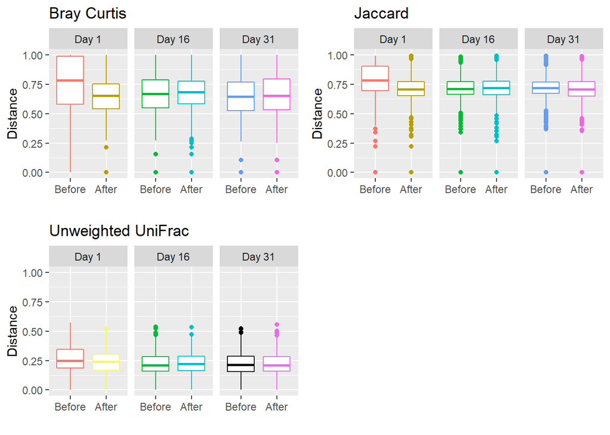

```r
grid.arrange(bray_curtis.box,jaccard.box,
             unweighted_unifrac.box,
             ncol = 2)
```

Statistical tests for testing whether the distributions of each beta diversity metric were significantly different between different sampling points

```r
#Mann-Whitney U tests for all beta metrics
compare_means(value ~ day, bray_curtis.grouped.melted, method = "wilcox.test", group.by = "ba")
```

```
## # A tibble: 6 x 9
##   ba     .y.   group1 group2        p    p.adj p.format p.signif method
##   <chr>  <chr> <chr>  <chr>     <dbl>    <dbl> <chr>    <chr>    <chr>
## 1 After  value Day 1  Day 16 3.27e- 3 1.30e- 2 0.0033   **       Wilcoxon
## 2 After  value Day 1  Day 31 1.38e- 1 3.10e- 1 0.1376   ns       Wilcoxon
## 3 After  value Day 16 Day 31 2.00e- 1 3.10e- 1 0.1998   ns       Wilcoxon
## 4 Before value Day 1  Day 16 3.38e-13 1.70e-12 3.4e-13  ****     Wilcoxon
## 5 Before value Day 1  Day 31 2.40e-17 1.40e-16 < 2e-16  ****     Wilcoxon
## 6 Before value Day 16 Day 31 1.04e- 1 3.10e- 1 0.1038   ns       Wilcoxon
```

```r
compare_means(value ~ day, generalized_unifrac.grouped.melted, method = "wilcox.test", group.by = "ba")
```

```
## # A tibble: 6 x 9
##   ba     .y.   group1 group2        p        p.adj p.format p.signif method
##   <chr>  <chr> <chr>  <chr>     <dbl>        <dbl> <chr>    <chr>    <chr>
## 1 After  value Day 1  Day 16 4.18e- 2 0.13         0.0418   *        Wilcoxon
## 2 After  value Day 1  Day 31 6.23e- 3 0.025        0.0062   **       Wilcoxon
## 3 After  value Day 16 Day 31 4.72e- 1 0.94         0.4719   ns       Wilcoxon
## 4 Before value Day 1  Day 16 4.31e-10 0.0000000026 4.3e-10  ****     Wilcoxon
## 5 Before value Day 1  Day 31 1.61e- 9 0.0000000081 1.6e-09  ****     Wilcoxon
## 6 Before value Day 16 Day 31 5.67e- 1 0.94         0.5670   ns       Wilcoxon
```

```r
compare_means(value ~ day, jaccard.grouped.melted, method = "wilcox.test", group.by = "ba")
```

```
## # A tibble: 6 x 9
##   ba     .y.   group1 group2        p    p.adj p.format p.signif method
##   <chr>  <chr> <chr>  <chr>     <dbl>    <dbl> <chr>    <chr>    <chr>
## 1 After  value Day 1  Day 16 1.18e- 1 4.70e- 1 0.12     ns       Wilcoxon
## 2 After  value Day 1  Day 31 6.19e- 1 1.00e+ 0 0.62     ns       Wilcoxon
## 3 After  value Day 16 Day 31 3.10e- 1 9.30e- 1 0.31     ns       Wilcoxon
## 4 Before value Day 1  Day 16 1.24e-17 6.50e-17 <2e-16   ****     Wilcoxon
## 5 Before value Day 1  Day 31 1.09e-17 6.50e-17 <2e-16   ****     Wilcoxon
## 6 Before value Day 16 Day 31 5.46e- 1 1.00e+ 0 0.55     ns       Wilcoxon
```

```r
compare_means(value ~ day, unweighted_unifrac.grouped.melted, method = "wilcox.test", group.by = "ba")
```

```
## # A tibble: 6 x 9
##   ba     .y.   group1 group2        p        p.adj p.format p.signif method
##   <chr>  <chr> <chr>  <chr>     <dbl>        <dbl> <chr>    <chr>    <chr>
## 1 After  value Day 1  Day 16 5.94e- 2 0.18         0.0594   ns       Wilcoxon
## 2 After  value Day 1  Day 31 4.83e- 3 0.019        0.0048   **       Wilcoxon
## 3 After  value Day 16 Day 31 3.40e- 1 0.68         0.3396   ns       Wilcoxon
## 4 Before value Day 1  Day 16 3.75e-10 0.0000000022 3.7e-10  ****     Wilcoxon
## 5 Before value Day 1  Day 31 3.71e- 9 0.000000019  3.7e-09  ****     Wilcoxon
## 6 Before value Day 16 Day 31 4.43e- 1 0.68         0.4432   ns       Wilcoxon
```

```r
compare_means(value ~ day, weighted_normalized_unifrac.grouped.melted, method = "wilcox.test", group.by = "ba")
```

```
## # A tibble: 6 x 9
##   ba     .y.   group1 group2        p        p.adj p.format p.signif method
##   <chr>  <chr> <chr>  <chr>     <dbl>        <dbl> <chr>    <chr>    <chr>
## 1 After  value Day 1  Day 16 4.18e- 2 0.13         0.0418   *        Wilcoxon
## 2 After  value Day 1  Day 31 6.23e- 3 0.025        0.0062   **       Wilcoxon
## 3 After  value Day 16 Day 31 4.72e- 1 0.94         0.4719   ns       Wilcoxon
## 4 Before value Day 1  Day 16 4.31e-10 0.0000000026 4.3e-10  ****     Wilcoxon
## 5 Before value Day 1  Day 31 1.61e- 9 0.0000000081 1.6e-09  ****     Wilcoxon
## 6 Before value Day 16 Day 31 5.67e- 1 0.94         0.5670   ns       Wilcoxon
```

```r
compare_means(value ~ day, weighted_unifrac.grouped.melted, method = "wilcox.test", group.by = "ba")
```

```
## # A tibble: 6 x 9
##   ba     .y.   group1 group2        p        p.adj p.format p.signif method
##   <chr>  <chr> <chr>  <chr>     <dbl>        <dbl> <chr>    <chr>    <chr>
## 1 After  value Day 1  Day 16 5.94e- 2 0.18         0.0594   ns       Wilcoxon
## 2 After  value Day 1  Day 31 4.83e- 3 0.019        0.0048   **       Wilcoxon
## 3 After  value Day 16 Day 31 3.40e- 1 0.68         0.3396   ns       Wilcoxon
## 4 Before value Day 1  Day 16 3.75e-10 0.0000000022 3.7e-10  ****     Wilcoxon
## 5 Before value Day 1  Day 31 3.71e- 9 0.000000019  3.7e-09  ****     Wilcoxon
## 6 Before value Day 16 Day 31 4.43e- 1 0.68         0.4432   ns       Wilcoxon
```

```r
compare_means(value ~ group, bray_curtis.grouped.melted, method = "wilcox.test", group.by = "day")
```

```
## # A tibble: 3 x 9
##   day    .y.   group1      group2           p    p.adj p.format p.signif method
##   <chr>  <chr> <chr>       <chr>        <dbl>    <dbl> <chr>    <chr>    <chr>
## 1 Day 1  value Before Day~ After Da~ 9.72e-16 2.90e-15 9.7e-16  ****     Wilcox~
## 2 Day 16 value Before Day~ After Da~ 2.98e- 1 3.00e- 1 0.30     ns       Wilcox~
## 3 Day 31 value Before Day~ After Da~ 1.40e- 1 2.80e- 1 0.14     ns       Wilcox~
```

```r
compare_means(value ~ group, generalized_unifrac.grouped.melted, method = "wilcox.test", group.by = "day")
```

```
## # A tibble: 3 x 9
##   day    .y.   group1       group2           p   p.adj p.format p.signif method
##   <chr>  <chr> <chr>        <chr>        <dbl>   <dbl> <chr>    <chr>    <chr>
## 1 Day 1  value Before Day 1 After Day~ 0.00159 0.00480 0.0016   **       Wilcox~
## 2 Day 16 value Before Day ~ After Day~ 0.241   0.48    0.2413   ns       Wilcox~
## 3 Day 31 value Before Day ~ After Day~ 0.942   0.94    0.9422   ns       Wilcox~
```

```r
compare_means(value ~ group, jaccard.grouped.melted, method = "wilcox.test", group.by = "day")
```

```
## # A tibble: 3 x 9
##   day    .y.   group1      group2           p    p.adj p.format p.signif method
##   <chr>  <chr> <chr>       <chr>        <dbl>    <dbl> <chr>    <chr>    <chr>
## 1 Day 1  value Before Day~ After Da~ 3.17e-18 9.50e-18 <2e-16   ****     Wilcox~
## 2 Day 16 value Before Day~ After Da~ 4.66e- 1 4.70e- 1 0.47     ns       Wilcox~
## 3 Day 31 value Before Day~ After Da~ 2.33e- 1 4.70e- 1 0.23     ns       Wilcox~
```

```r
compare_means(value ~ group, unweighted_unifrac.grouped.melted, method = "wilcox.test", group.by = "day")
```

```
## # A tibble: 3 x 9
##   day    .y.   group1        group2            p p.adj p.format p.signif method
##   <chr>  <chr> <chr>         <chr>         <dbl> <dbl> <chr>    <chr>    <chr>
## 1 Day 1  value Before Day 1  After Day 1 0.00167 0.005 0.0017   **       Wilcox~
## 2 Day 16 value Before Day 16 After Day ~ 0.175   0.35  0.1755   ns       Wilcox~
## 3 Day 31 value Before Day 31 After Day ~ 0.753   0.75  0.7532   ns       Wilcox~
```

```r
compare_means(value ~ group, weighted_normalized_unifrac.grouped.melted, method = "wilcox.test", group.by = "day")
```

```
## # A tibble: 3 x 9
##   day    .y.   group1       group2           p   p.adj p.format p.signif method
##   <chr>  <chr> <chr>        <chr>        <dbl>   <dbl> <chr>    <chr>    <chr>
## 1 Day 1  value Before Day 1 After Day~ 0.00159 0.00480 0.0016   **       Wilcox~
## 2 Day 16 value Before Day ~ After Day~ 0.241   0.48    0.2413   ns       Wilcox~
## 3 Day 31 value Before Day ~ After Day~ 0.942   0.94    0.9422   ns       Wilcox~
```

```r
compare_means(value ~ group, weighted_unifrac.grouped.melted, method = "wilcox.test", group.by = "day")
```

```
## # A tibble: 3 x 9
##   day    .y.   group1        group2            p p.adj p.format p.signif method
##   <chr>  <chr> <chr>         <chr>         <dbl> <dbl> <chr>    <chr>    <chr>
## 1 Day 1  value Before Day 1  After Day 1 0.00167 0.005 0.0017   **       Wilcox~
## 2 Day 16 value Before Day 16 After Day ~ 0.175   0.35  0.1755   ns       Wilcox~
## 3 Day 31 value Before Day 31 After Day ~ 0.753   0.75  0.7532   ns       Wilcox~
```